# 📊 **Experiment Analysis (UR20, UR21, UR22, UR23)**

This notebook summarizes and analyzes the SQL baseline experiment results for  
**UR20**, **UR21**, **UR22**, and **UR23**.

## 🔍 **What was run**

We executed all combinations of:

- **14 split types**  
  *(the number indicates how many sources the base table was divided into)*
  - `random_5`
  - `random_10`
  - `random_20`
  - `random_100`
  - `skewed_5`
  - `skewed_10`
  - `skewed_20`
  - `skewed_100`
  - `high_pen_5`
  - `high_pen_20`
  - `low_pen_5`
  - `low_pen_20`
  - `low_cov_5`
  - `low_cov_20`
- **θ thresholds:** `0.7`, `0.8`, `0.9`
- **2 methods:**
  - *Classic:* `method1_full_scan`
  - *Stats-guided:* `method1_full_scan_stats`

For every (UR, split, θ, method) combination, the system recorded:

- Runtime
- Sources explored
- Coverage
- Penalty
- Rows returned
- Shipping time
- Local processing time

Load and clean the experiment summary

```python
import os
os.getcwd()
```

```
'/Users/ahmaddfaress/Desktop/TVD/Analysis'
```

```python
import pandas as pd
import numpy as np
import matplotlib.pyplot as plt
import seaborn as sns

df = pd.read_csv("/Users/ahmaddfaress/Desktop/TVD/data/experiment_results/Experiment1.csv")

numeric_cols = [
    "sources_explored", "shipping_time_total", "shipping_rows_total",
    "local_time_total", "method_time_total", "rows_final",
    "coverage_final", "penalty_final", "runtime_total"
]
df[numeric_cols] = df[numeric_cols].apply(pd.to_numeric)

df.head()
```

|  | UR_id | dataset | split | n_sources | theta | method | sources_explored | shipping_time_total | shipping_rows_total | local_time_total | method_time_total | rows_final | coverage_final | penalty_final | runtime_total |
| --- | --- | --- | --- | --- | --- | --- | --- | --- | --- | --- | --- | --- | --- | --- | --- |
| 0 | 20 | MATHE | random_10 | 10 | 0.7 | method1_full_scan | 10 | 0.056237 | 20255 | 21.479059 | 21.535297 | 10 | 0.916667 | 0.565079 | 21.558967 |
| 1 | 20 | MATHE | random_10 | 10 | 0.7 | method1_full_scan_stats | 1 | 0.006691 | 2026 | 0.423260 | 0.429951 | 10 | 0.916667 | 0.488889 | 0.445429 |
| 2 | 20 | MATHE | random_10 | 10 | 0.8 | method1_full_scan | 10 | 0.054639 | 20255 | 21.321747 | 21.376386 | 10 | 0.916667 | 0.565079 | 21.388575 |
| 3 | 20 | MATHE | random_10 | 10 | 0.8 | method1_full_scan_stats | 1 | 0.004832 | 2026 | 0.411692 | 0.416524 | 10 | 0.916667 | 0.488889 | 0.433005 |
| 4 | 20 | MATHE | random_10 | 10 | 0.9 | method1_full_scan | 10 | 0.052601 | 20255 | 20.966385 | 21.018986 | 10 | 0.916667 | 0.565079 | 21.029174 |

Overview of Runs

```python
print("URs:", df["UR_id"].unique())
print("Splits:", df["split"].unique())
print("Thetas:", df["theta"].unique())
print("Methods:", df["method"].unique())
print("Total runs:", len(df))
```

```
URs: [20 21 22 23]
Splits: ['random_10' 'random_100' 'random_20' 'random_5' 'skewed_10' 'skewed_100'
 'skewed_20' 'skewed_5' 'high_penalty_20' 'high_penalty_5'
 'low_coverage_20' 'low_coverage_5' 'low_penalty_20' 'low_penalty_5']
Thetas: [0.7 0.8 0.9]
Methods: ['method1_full_scan' 'method1_full_scan_stats']
Total runs: 337
```

```python
avg_shipping = df["shipping_time_total"].mean()
avg_local = df["local_time_total"].mean()

overall = pd.DataFrame({
    "metric": ["average_shipping_time", "average_local_time"],
    "value": [avg_shipping, avg_local]
})

overall
```

|  | metric | value |
| --- | --- | --- |
| 0 | average_shipping_time | 0.045271 |
| 1 | average_local_time | 15.605745 |

Sources explored (Stat vs Non-Stat)

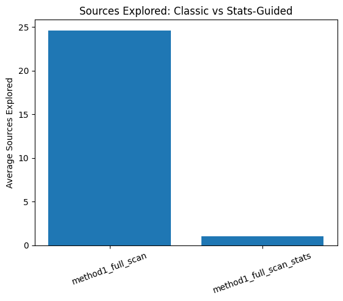

```python
avg_sources = (
    df.groupby("method")["sources_explored"]
      .mean()
      .rename("avg_sources_explored")
)

import matplotlib.pyplot as plt

methods = avg_sources.index
values = avg_sources.values

plt.bar(methods, values)
plt.ylabel("Average Sources Explored")
plt.title("Sources Explored: Classic vs Stats-Guided")
plt.xticks(rotation=20)
plt.show()
```

Shipping cost (Stat vs Non Stat) -- Since we explore less sources both the shipping cost and the local cost will be way less in stat version

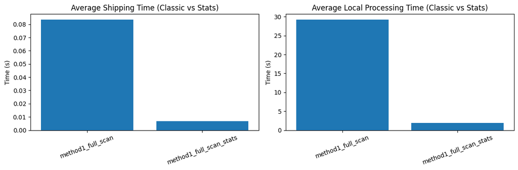

```python
import matplotlib.pyplot as plt
avg_costs = (
    df.groupby("method")[["shipping_time_total", "local_time_total"]]
      .mean()
      .rename(columns={
          "shipping_time_total": "avg_shipping_time",
          "local_time_total": "avg_local_time"
      })
)


fig, ax = plt.subplots(1, 2, figsize=(12,4))

# --- Shipping time ---
ax[0].bar(avg_costs.index, avg_costs["avg_shipping_time"])
ax[0].set_title("Average Shipping Time (Classic vs Stats)")
ax[0].set_ylabel("Time (s)")
ax[0].tick_params(axis="x", rotation=20)

# --- Local time ---
ax[1].bar(avg_costs.index, avg_costs["avg_local_time"])
ax[1].set_title("Average Local Processing Time (Classic vs Stats)")
ax[1].set_ylabel("Time (s)")
ax[1].tick_params(axis="x", rotation=20)

plt.tight_layout()
plt.show()
```

Now we check the quality of the results of the methods.

```python
avg_quality = (
    df.groupby("method")[["coverage_final", "penalty_final"]]
      .mean()
      .rename(columns={
          "coverage_final": "avg_coverage",
          "penalty_final": "avg_penalty"
      })
)

avg_quality
```

| method | avg_coverage | avg_penalty |
| --- | --- | --- |
| method1_full_scan | 0.890110 | 0.486740 |
| method1_full_scan_stats | 0.887755 | 0.548649 |

And its graph in the code below

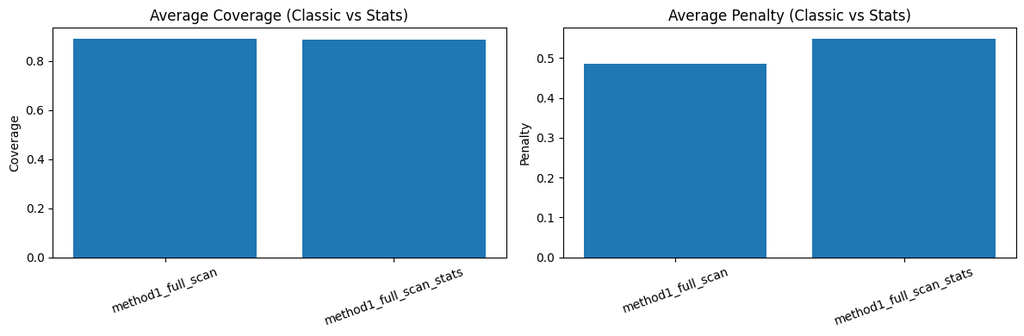

```python
import matplotlib.pyplot as plt

fig, ax = plt.subplots(1, 2, figsize=(12,4))

# --- Coverage ---
ax[0].bar(avg_quality.index, avg_quality["avg_coverage"])
ax[0].set_title("Average Coverage (Classic vs Stats)")
ax[0].set_ylabel("Coverage")
ax[0].tick_params(axis="x", rotation=20)

# --- Penalty ---
ax[1].bar(avg_quality.index, avg_quality["avg_penalty"])
ax[1].set_title("Average Penalty (Classic vs Stats)")
ax[1].set_ylabel("Penalty")
ax[1].tick_params(axis="x", rotation=20)

plt.tight_layout()
plt.show()
```

The Average coverage of both methods is nearly the same, while as visible exploring less sources gives the algorithm less chance to explore more rows that can potentially decrease the penalty. Thus we see the full scan yields a lower average penalty.

Now Deep UR (20-21) VS Shallow UR (22-23)

```python
# Deep & shallow groupings
deep_urs = [20, 21]
shallow_urs = [22, 23]

df_deep = df[df["UR_id"].isin(deep_urs)].copy()
df_shallow = df[df["UR_id"].isin(shallow_urs)].copy()

print("Deep UR rows:", len(df_deep))
print("Shallow UR rows:", len(df_shallow))
```

```
Deep UR rows: 168
Shallow UR rows: 169
```

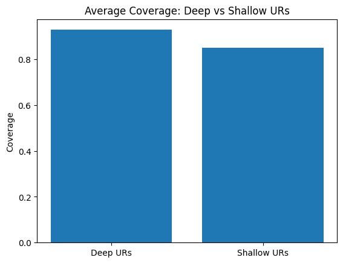

```
Deep coverage: 0.9285714285714286
Shallow coverage: 0.849535080304311
```

```python
import matplotlib.pyplot as plt

avg_cov_deep = df_deep["coverage_final"].mean()
avg_cov_shallow = df_shallow["coverage_final"].mean()

plt.bar(["Deep URs", "Shallow URs"], [avg_cov_deep, avg_cov_shallow])
plt.title("Average Coverage: Deep vs Shallow URs")
plt.ylabel("Coverage")
plt.show()

print("Deep coverage:", avg_cov_deep)
print("Shallow coverage:", avg_cov_shallow)
```

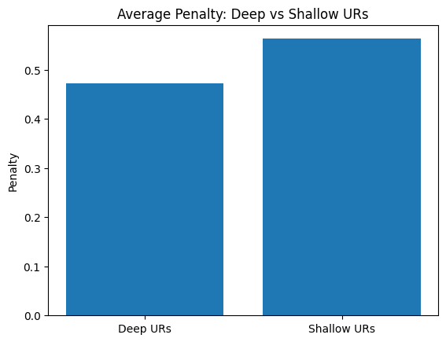

```
Deep penalty: 0.47207577475434614
Shallow penalty: 0.5628607656080182
```

```python
avg_pen_deep = df_deep["penalty_final"].mean()
avg_pen_shallow = df_shallow["penalty_final"].mean()

plt.bar(["Deep URs", "Shallow URs"], [avg_pen_deep, avg_pen_shallow])
plt.title("Average Penalty: Deep vs Shallow URs")
plt.ylabel("Penalty")
plt.show()

print("Deep penalty:", avg_pen_deep)
print("Shallow penalty:", avg_pen_shallow)
```

As expected, shallow URs have potential to yield more penalty, since it has more attributes.

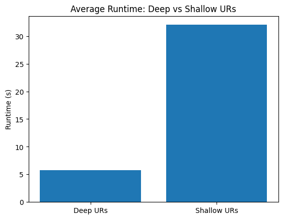

```
Deep runtime: 5.795018193267641
Shallow runtime: 32.03351168801799
```

```python
avg_rt_deep = df_deep["runtime_total"].mean()
avg_rt_shallow = df_shallow["runtime_total"].mean()

plt.bar(["Deep URs", "Shallow URs"], [avg_rt_deep, avg_rt_shallow])
plt.title("Average Runtime: Deep vs Shallow URs")
plt.ylabel("Runtime (s)")
plt.show()

print("Deep runtime:", avg_rt_deep)
print("Shallow runtime:", avg_rt_shallow)
```

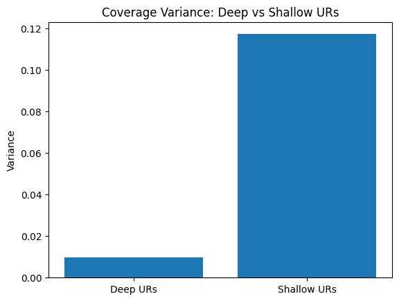

```
Deep coverage variance: 0.009837467921300257
Shallow coverage variance: 0.11728871599358255
```

```python
import numpy as np

var_deep = df_deep["coverage_final"].var()
var_shallow = df_shallow["coverage_final"].var()

plt.bar(["Deep URs", "Shallow URs"], [var_deep, var_shallow])
plt.title("Coverage Variance: Deep vs Shallow URs")
plt.ylabel("Variance")
plt.show()

print("Deep coverage variance:", var_deep)
print("Shallow coverage variance:", var_shallow)
```

Now some analysis on Split types:

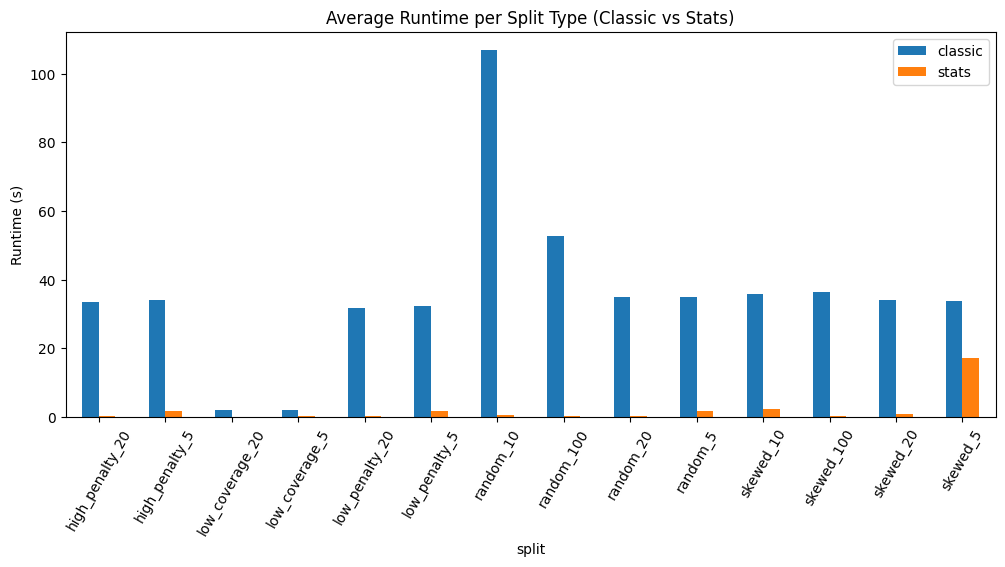

| split | classic | stats |
| --- | --- | --- |
| high_penalty_20 | 33.590561 | 0.226264 |
| high_penalty_5 | 34.201193 | 1.690292 |
| low_coverage_20 | 1.961687 | 0.056979 |
| low_coverage_5 | 2.117619 | 0.193497 |
| low_penalty_20 | 31.809243 | 0.221056 |
| low_penalty_5 | 32.187297 | 1.661463 |
| random_10 | 106.908190 | 0.540983 |
| random_100 | 52.597513 | 0.146196 |
| random_20 | 34.831053 | 0.227895 |
| random_5 | 35.058437 | 1.729572 |
| skewed_10 | 35.782517 | 2.286713 |
| skewed_100 | 36.252912 | 0.238304 |
| skewed_20 | 33.940610 | 0.705264 |
| skewed_5 | 33.909483 | 17.032611 |

```python
import matplotlib.pyplot as plt
import pandas as pd

classic = df[df["method"] == "method1_full_scan"]
stats = df[df["method"] == "method1_full_scan_stats"]

runtime_by_split = pd.DataFrame({
    "classic": classic.groupby("split")["runtime_total"].mean(),
    "stats": stats.groupby("split")["runtime_total"].mean(),
})

runtime_by_split.plot(kind="bar", figsize=(12,5))
plt.title("Average Runtime per Split Type (Classic vs Stats)")
plt.ylabel("Runtime (s)")
plt.xticks(rotation=60)
plt.show()

runtime_by_split
```

[figure not shown]

```
split
low_penalty_20     0.000000
low_penalty_5      0.000000
high_penalty_20    0.001359
high_penalty_5     0.001359
random_10          0.001359
random_5           0.001359
skewed_10          0.001359
skewed_20          0.001359
skewed_5           0.001359
random_100         0.002911
random_20          0.002911
skewed_100         0.002911
low_coverage_5     0.119593
low_coverage_20    0.120146
Name: coverage_final, dtype: float64
```

```python
coverage_variance = df.groupby("split")["coverage_final"].var().sort_values()

plt.figure(figsize=(12,5))
plt.bar(coverage_variance.index, coverage_variance.values)
plt.title("Coverage Variance per Split Type")
plt.ylabel("Variance")
plt.xticks(rotation=60)
plt.show()

coverage_variance
```

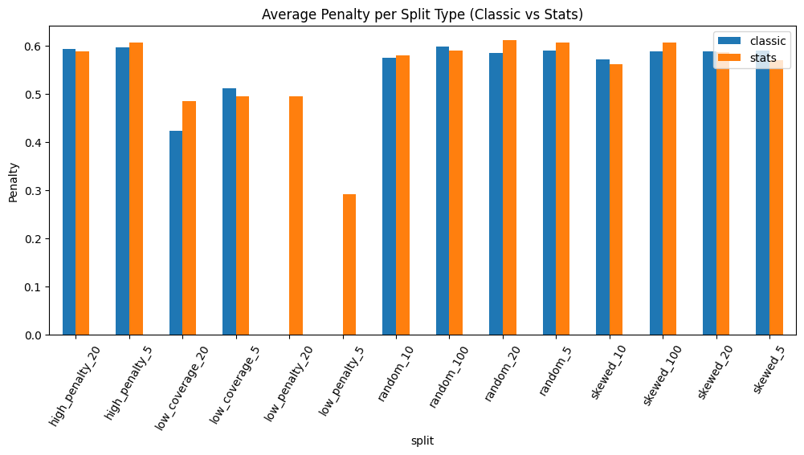

| split | classic | stats |
| --- | --- | --- |
| high_penalty_20 | 0.594114 | 0.589153 |
| high_penalty_5 | 0.597090 | 0.607039 |
| low_coverage_20 | 0.424451 | 0.484821 |
| low_coverage_5 | 0.511905 | 0.495238 |
| low_penalty_20 | 0.000000 | 0.496060 |
| low_penalty_5 | 0.000000 | 0.291071 |
| random_10 | 0.575463 | 0.580055 |
| random_100 | 0.598280 | 0.590146 |
| random_20 | 0.586177 | 0.611971 |
| random_5 | 0.591138 | 0.607039 |
| skewed_10 | 0.572487 | 0.562198 |
| skewed_100 | 0.589153 | 0.607011 |
| skewed_20 | 0.588161 | 0.587991 |
| skewed_5 | 0.591138 | 0.571296 |

```python
penalty_by_split = pd.DataFrame({
    "classic": classic.groupby("split")["penalty_final"].mean(),
    "stats": stats.groupby("split")["penalty_final"].mean(),
})

penalty_by_split.plot(kind="bar", figsize=(12,5))
plt.title("Average Penalty per Split Type (Classic vs Stats)")
plt.ylabel("Penalty")
plt.xticks(rotation=60)
plt.show()

penalty_by_split
```

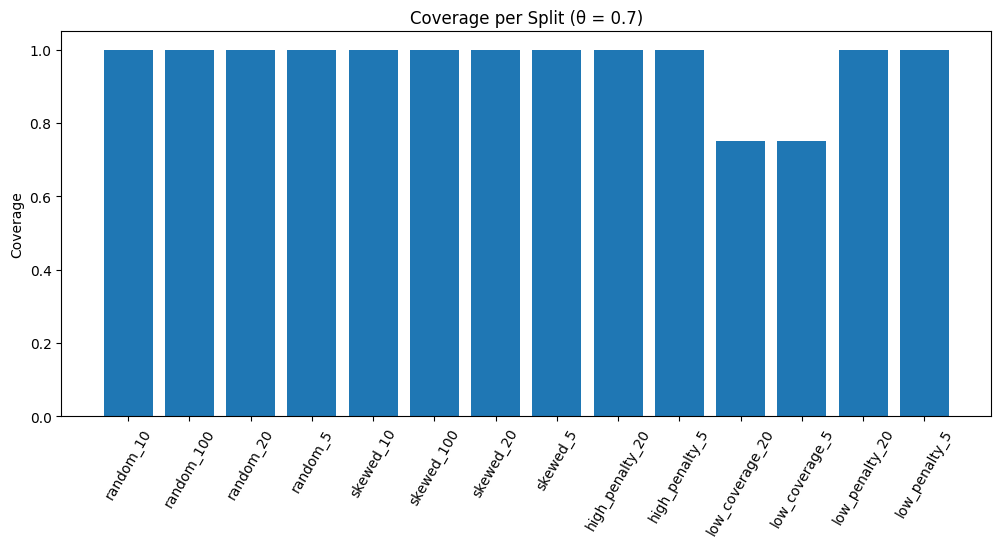

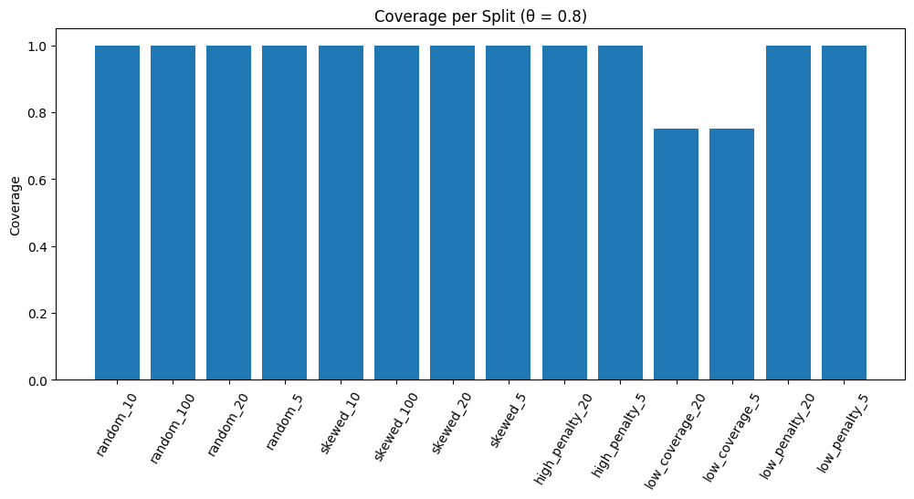

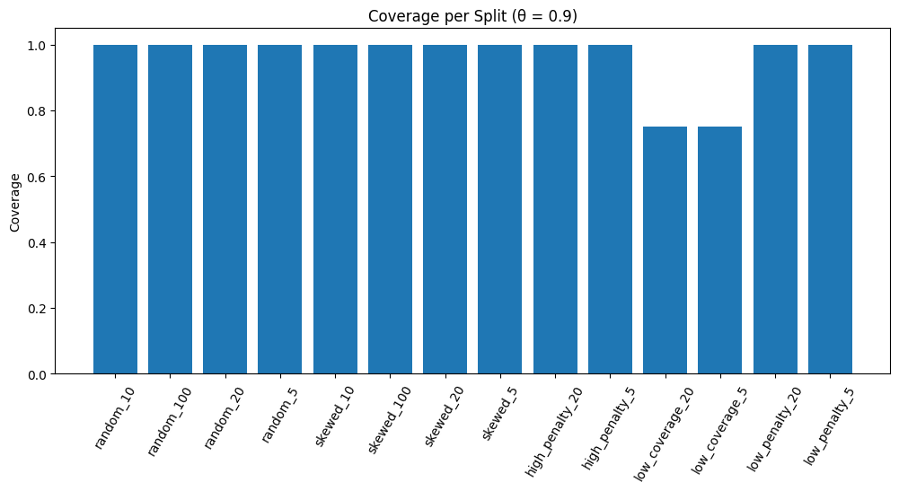

```python
import matplotlib.pyplot as plt
import pandas as pd

for theta in sorted(df["theta"].unique()):
    sub = df[df["theta"] == theta]

    plt.figure(figsize=(12,5))
    plt.bar(sub["split"], sub["coverage_final"])
    plt.xticks(rotation=60)
    plt.title(f"Coverage per Split (θ = {theta})")
    plt.ylabel("Coverage")
    plt.show()
```

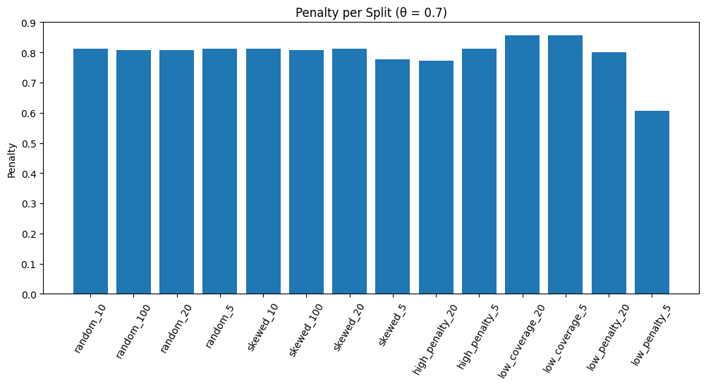

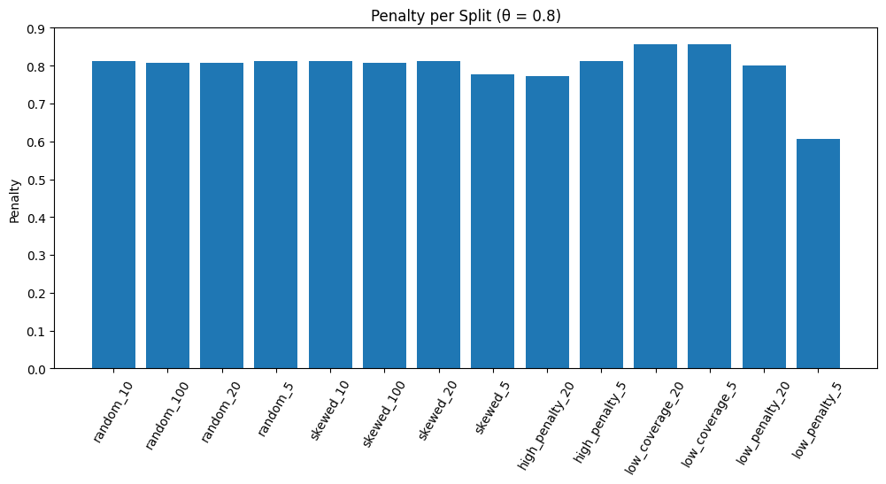

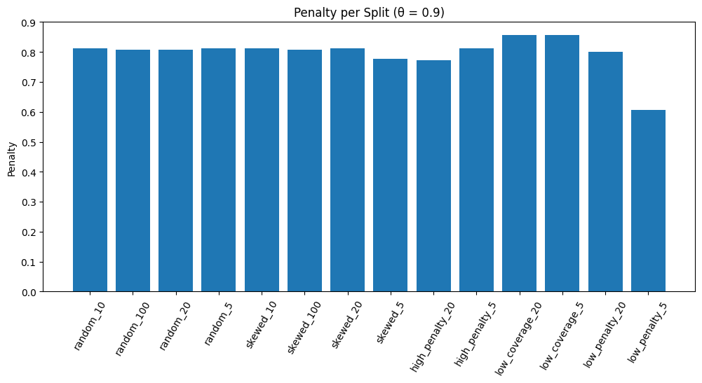

```python
for theta in sorted(df["theta"].unique()):
    sub = df[df["theta"] == theta]

    plt.figure(figsize=(12,5))
    plt.bar(sub["split"], sub["penalty_final"])
    plt.xticks(rotation=60)
    plt.title(f"Penalty per Split (θ = {theta})")
    plt.ylabel("Penalty")
    plt.show()
```

Theta does not show much difference as it varies, since we are exploring everything. I will try to see it with only stat version.

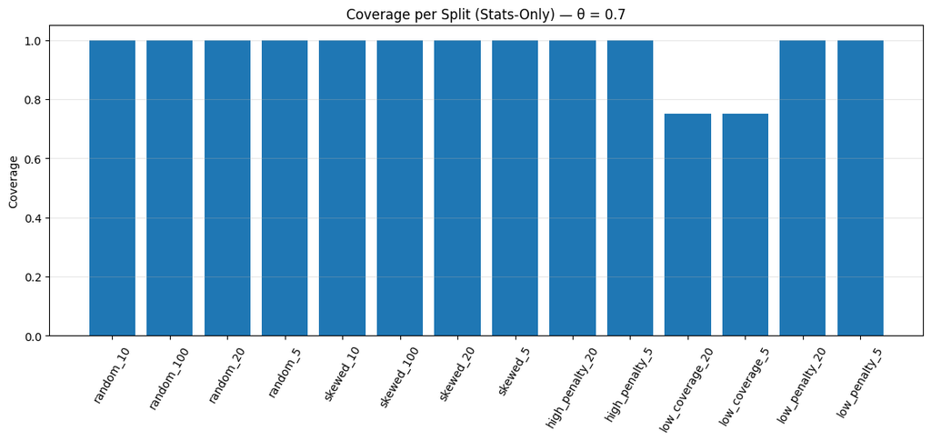

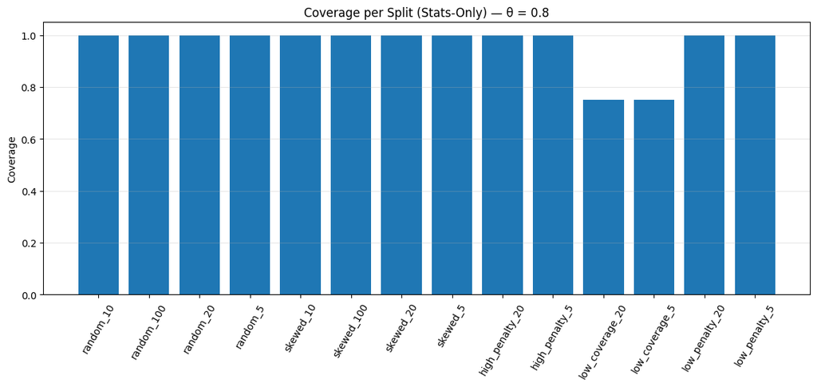

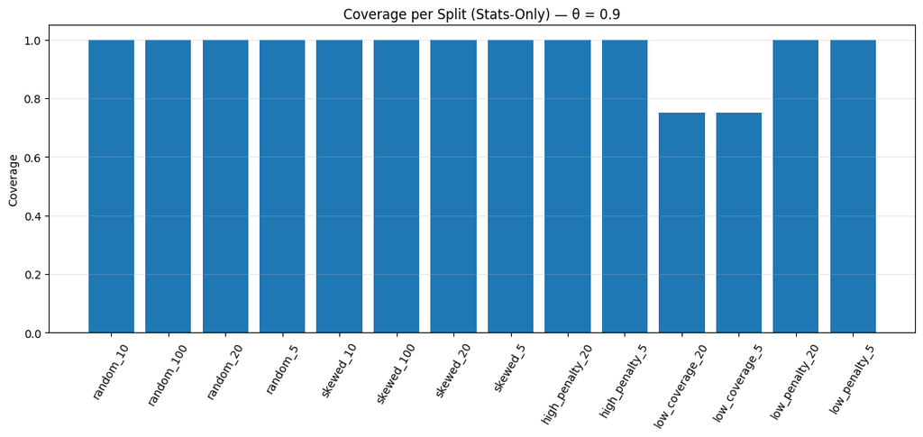

```python
import matplotlib.pyplot as plt

# keep only stat-guided
df_stat = df[df["method"] == "method1_full_scan_stats"]

for theta in sorted(df_stat["theta"].unique()):
    sub = df_stat[df_stat["theta"] == theta]

    plt.figure(figsize=(14,5))
    plt.bar(sub["split"], sub["coverage_final"])
    plt.xticks(rotation=60)
    plt.title(f"Coverage per Split (Stats-Only) — θ = {theta}")
    plt.ylabel("Coverage")
    plt.ylim(0, 1.05)
    plt.grid(axis='y', alpha=0.3)
    plt.show()
```

Also not much difference, but it is dataset and UR dependent...